# Wine Count Regression

Mary Anna Kivenson

May 3, 2020

# Data Exploration

```r
df <- read.csv("https://raw.githubusercontent.com/mkivenson/Business-Analytics-Data-Mining/master/Wine%20Count%20Regression/Datasets/wine-training-data.csv")[,-1] # drop the first column, it is the index
head(df)
```

```
##   TARGET FixedAcidity VolatileAcidity CitricAcid ResidualSugar Chlorides
## 1      3          3.2           1.160      -0.98          54.2    -0.567
## 2      3          4.5           0.160      -0.81          26.1    -0.425
## 3      5          7.1           2.640      -0.88          14.8     0.037
## 4      3          5.7           0.385       0.04          18.8    -0.425
## 5      4          8.0           0.330      -1.26           9.4        NA
## 6      0         11.3           0.320       0.59           2.2     0.556
##   FreeSulfurDioxide TotalSulfurDioxide Density   pH Sulphates Alcohol
## 1                NA                268 0.99280 3.33     -0.59     9.9
## 2                15               -327 1.02792 3.38      0.70      NA
## 3               214                142 0.99518 3.12      0.48    22.0
## 4                22                115 0.99640 2.24      1.83     6.2
## 5              -167                108 0.99457 3.12      1.77    13.7
## 6               -37                 15 0.99940 3.20      1.29    15.4
##   LabelAppeal AcidIndex STARS
## 1           0         8     2
## 2          -1         7     3
## 3          -1         8     3
## 4          -1         6     1
## 5           0         9     2
## 6           0        11    NA
```

Taking a look at a summary of the data, there seem to be many missing values in the `ResidualSugar`,`Chlorides`,`FreeSulfurDioxide`,`TotalSulfurDioxide`,`pH`,`Sulphates`,`Alcohol`, and `STARS` fields. The `STARS` and `LabelAppeal` columns are both ordinal variables and may need to be transformed into dummy variables.

```r
summary(df)
```

```
##      TARGET       FixedAcidity     VolatileAcidity     CitricAcid
##  Min.   :0.000   Min.   :-18.100   Min.   :-2.7900   Min.   :-3.2400
##  1st Qu.:2.000   1st Qu.:  5.200   1st Qu.: 0.1300   1st Qu.: 0.0300
##  Median :3.000   Median :  6.900   Median : 0.2800   Median : 0.3100
##  Mean   :3.029   Mean   :  7.076   Mean   : 0.3241   Mean   : 0.3084
##  3rd Qu.:4.000   3rd Qu.:  9.500   3rd Qu.: 0.6400   3rd Qu.: 0.5800
##  Max.   :8.000   Max.   : 34.400   Max.   : 3.6800   Max.   : 3.8600
##
##  ResidualSugar        Chlorides       FreeSulfurDioxide TotalSulfurDioxide
##  Min.   :-127.800   Min.   :-1.1710   Min.   :-555.00   Min.   :-823.0
##  1st Qu.:  -2.000   1st Qu.:-0.0310   1st Qu.:   0.00   1st Qu.:  27.0
##  Median :   3.900   Median : 0.0460   Median :  30.00   Median : 123.0
##  Mean   :   5.419   Mean   : 0.0548   Mean   :  30.85   Mean   : 120.7
##  3rd Qu.:  15.900   3rd Qu.: 0.1530   3rd Qu.:  70.00   3rd Qu.: 208.0
##  Max.   : 141.150   Max.   : 1.3510   Max.   : 623.00   Max.   :1057.0
##  NA's   :616        NA's   :638       NA's   :647       NA's   :682
##     Density             pH          Sulphates          Alcohol
##  Min.   :0.8881   Min.   :0.480   Min.   :-3.1300   Min.   :-4.70
##  1st Qu.:0.9877   1st Qu.:2.960   1st Qu.: 0.2800   1st Qu.: 9.00
##  Median :0.9945   Median :3.200   Median : 0.5000   Median :10.40
##  Mean   :0.9942   Mean   :3.208   Mean   : 0.5271   Mean   :10.49
##  3rd Qu.:1.0005   3rd Qu.:3.470   3rd Qu.: 0.8600   3rd Qu.:12.40
##  Max.   :1.0992   Max.   :6.130   Max.   : 4.2400   Max.   :26.50
##                   NA's   :395     NA's   :1210      NA's   :653
##   LabelAppeal          AcidIndex          STARS
##  Min.   :-2.000000   Min.   : 4.000   Min.   :1.000
##  1st Qu.:-1.000000   1st Qu.: 7.000   1st Qu.:1.000
##  Median : 0.000000   Median : 8.000   Median :2.000
##  Mean   :-0.009066   Mean   : 7.773   Mean   :2.042
##  3rd Qu.: 1.000000   3rd Qu.: 8.000   3rd Qu.:3.000
##  Max.   : 2.000000   Max.   :17.000   Max.   :4.000
##                                       NA's   :3359
```

#### Distributions

The following histograms help visualize the distributions of numerical variables in this dataset. Many of the predictor variables have a narrow spread and have high occurances at the center of the distribution. Normalizing the data may help make the distributions of variables more normal.

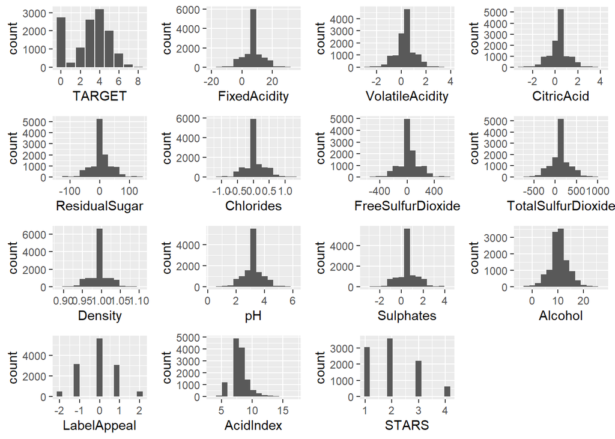

```r
grid.arrange(ggplot(df, aes(TARGET)) + geom_histogram(bins = 15, stat = "count"),
             ggplot(df, aes(FixedAcidity)) + geom_histogram(bins = 15),
             ggplot(df, aes(VolatileAcidity)) + geom_histogram(bins = 15),
             ggplot(df, aes(CitricAcid)) + geom_histogram(bins = 15),
             ggplot(df, aes(ResidualSugar)) + geom_histogram(bins = 15),
             ggplot(df, aes(Chlorides)) + geom_histogram(bins = 15),
             ggplot(df, aes(FreeSulfurDioxide)) + geom_histogram(bins = 15),
             ggplot(df, aes(TotalSulfurDioxide)) + geom_histogram(bins = 15),
             ggplot(df, aes(Density)) + geom_histogram(bins = 15),
             ggplot(df, aes(pH)) + geom_histogram(bins = 15),
             ggplot(df, aes(Sulphates)) + geom_histogram(bins = 15),
             ggplot(df, aes(Alcohol)) + geom_histogram(bins = 15),
             ggplot(df, aes(LabelAppeal)) + geom_histogram(bins = 15),
             ggplot(df, aes(AcidIndex)) + geom_histogram(bins = 15),
             ggplot(df, aes(STARS)) + geom_histogram(bins = 15),
             ncol=4)
```

#### Correlation Plot

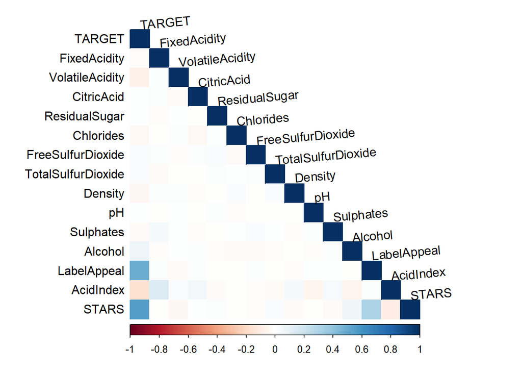

```r
corrplot(cor(df, use = "complete.obs"), method="color", type="lower", tl.col = "black", tl.srt = 5)
```

#### Box Plots

The weak correlations between most of the predictors and TARGET were suprising. The following box plots provide a more in-depth view at the relationship between predictors and the target variable. The plots confirm that the relationship between target and most of the features appears limited.

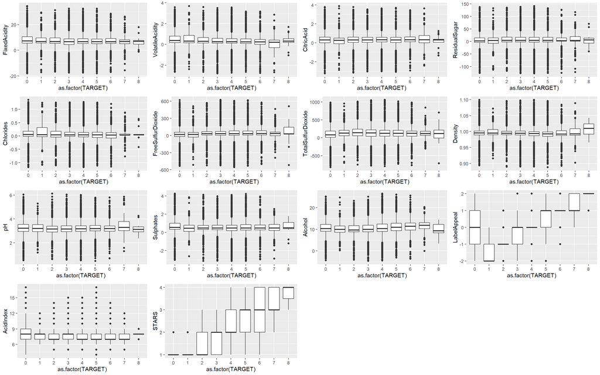

```r
grid.arrange(
             ggplot(df, aes(x = as.factor(TARGET), FixedAcidity)) +  geom_boxplot(),
             ggplot(df, aes(x = as.factor(TARGET), VolatileAcidity)) +  geom_boxplot(),
             ggplot(df, aes(x = as.factor(TARGET), CitricAcid)) +  geom_boxplot(),
             ggplot(df, aes(x = as.factor(TARGET), ResidualSugar)) +  geom_boxplot(),
             ggplot(df, aes(x = as.factor(TARGET), Chlorides)) +  geom_boxplot(),
             ggplot(df, aes(x = as.factor(TARGET), FreeSulfurDioxide)) +  geom_boxplot(),
             ggplot(df, aes(x = as.factor(TARGET), TotalSulfurDioxide)) +  geom_boxplot(),
             ggplot(df, aes(x = as.factor(TARGET), Density)) +  geom_boxplot(),
             ggplot(df, aes(x = as.factor(TARGET), pH)) +  geom_boxplot(),
             ggplot(df, aes(x = as.factor(TARGET), Sulphates)) +  geom_boxplot(),
             ggplot(df, aes(x = as.factor(TARGET), Alcohol)) +  geom_boxplot(),
             ggplot(df, aes(x = as.factor(TARGET), LabelAppeal)) +  geom_boxplot(),
             ggplot(df, aes(x = as.factor(TARGET), AcidIndex)) +  geom_boxplot(),
             ggplot(df, aes(x = as.factor(TARGET), STARS)) +  geom_boxplot(),
             ncol=4)
```

### Preprocessing

#### Train Test Split

```r
X_train <- subset(df, select = -c(TARGET))
y_train <- df$TARGET
```

#### Encoding

The `STARS` and `LabelAppeal` columns contain ordinal data. Using ordinal variables as-is in a model requires the assumption that categories are equally spaced. Since stars and label appeal are both subjective labels, this assumption may not hold true. To resolve this, these ordinal columns will be encoded into dummy variables.

```r
encode_wine_data <- function(df){

  #ENCODE STARS COLUMN. IF 0 IN ALL 4 COLUMNS, THIS VALUE IS MISSING
  df$STARS.1 <- replace_na(ifelse(df$STARS == '1', 1, 0),0)
  df$STARS.2 <- replace_na(ifelse(df$STARS == '2', 1, 0),0)
  df$STARS.3 <- replace_na(ifelse(df$STARS == '3', 1, 0),0)
  df$STARS.4 <- replace_na(ifelse(df$STARS == '4', 1, 0),0)


  #ENCODE LabelAppeal COLUMN
  df$LabelAppeal.N2 <- ifelse(df$LabelAppeal == '-2', 1, 0)
  df$LabelAppeal.N1 <- ifelse(df$LabelAppeal == '-1', 1, 0)
  df$LabelAppeal.P1 <- ifelse(df$LabelAppeal == '1', 1, 0)
  df$LabelAppeal.P2 <- ifelse(df$LabelAppeal == '2', 1, 0)


  df <- subset(df, select = -c(STARS, LabelAppeal))
  return(df)
}


X_train %>% encode_wine_data() %>% head()
```

```
##   FixedAcidity VolatileAcidity CitricAcid ResidualSugar Chlorides
## 1          3.2           1.160      -0.98          54.2    -0.567
## 2          4.5           0.160      -0.81          26.1    -0.425
## 3          7.1           2.640      -0.88          14.8     0.037
## 4          5.7           0.385       0.04          18.8    -0.425
## 5          8.0           0.330      -1.26           9.4        NA
## 6         11.3           0.320       0.59           2.2     0.556
##   FreeSulfurDioxide TotalSulfurDioxide Density   pH Sulphates Alcohol AcidIndex
## 1                NA                268 0.99280 3.33     -0.59     9.9         8
## 2                15               -327 1.02792 3.38      0.70      NA         7
## 3               214                142 0.99518 3.12      0.48    22.0         8
## 4                22                115 0.99640 2.24      1.83     6.2         6
## 5              -167                108 0.99457 3.12      1.77    13.7         9
## 6               -37                 15 0.99940 3.20      1.29    15.4        11
##   STARS.1 STARS.2 STARS.3 STARS.4 LabelAppeal.N2 LabelAppeal.N1 LabelAppeal.P1
## 1       0       1       0       0              0              0              0
## 2       0       0       1       0              0              1              0
## 3       0       0       1       0              0              1              0
## 4       1       0       0       0              0              1              0
## 5       0       1       0       0              0              0              0
## 6       0       0       0       0              0              0              0
##   LabelAppeal.P2
## 1              0
## 2              0
## 3              0
## 4              0
## 5              0
## 6              0
```

#### Missing Data

The following plots provide a visualization of missing data. There appears to be a patten in the mising values, so it will be useful to include a flag for missing data. KNN imputation is unsupervised, meaning it does not require a target variable. A train test split was performed earlier so that only predictor data is used for imputation.

[figure not shown]

[output not shown]

```r
aggr(encode_wine_data(X_train), col=c('navyblue','red'), numbers=TRUE, sortVars=TRUE, labels=names(df), cex.axis=.7, gap=3, ylab=c("Histogram of missing data","Pattern"))
```

```r
fill_wine_data <- function(df){
  df$missing_amt <- apply(df, 1, function(x) sum(is.na(x)))
  result <- preProcess(df, method = c("knnImpute"), k = 10)
  df <- predict(result, df)
  return(df)
}

X_train <- X_train %>% encode_wine_data() %>% fill_wine_data()
```